# ZierHW4

Emily Zier

November 1, 2015

```r
library(dplyr)
setwd("/Users/EmilyZier/Dropbox/Personal Computer/8120/Homeworks/HW4")
educ <- read.table("input/States.txt", header=TRUE)
educ <- educ %>% rename(sat.verbal = satVerbal, sat.math = satMath, percent.taking = percentTaking, percent.no.hs = percentNoHS, teacher.pay = teacherPay)
educ$state <- rownames(educ)
rownames(educ) <- NULL
educ <- tbl_df(educ)
```

Question 1.

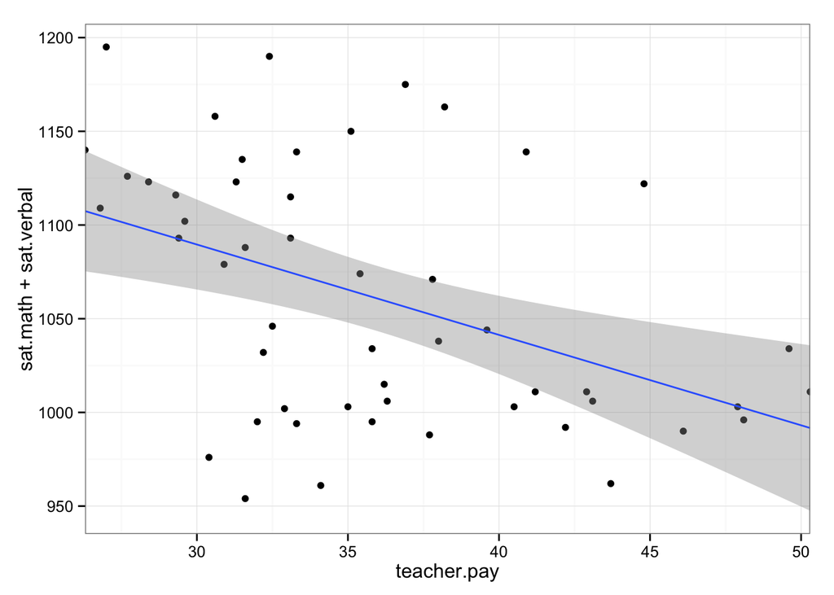

```r
library(ggplot2)
ggplot(educ,aes(x=teacher.pay,y=sat.math+sat.verbal)) + geom_point() +
  geom_smooth(method=lm) + theme_bw() + scale_x_continuous(expand=c(0,0))
```

Question 2.

```r
educ = educ %>% mutate(sat.mathandverbal = sat.math+sat.verbal)
model1 = lm(sat.mathandverbal~teacher.pay, data=educ)
summary(model1)
```

```
##
## Call:
## lm(formula = sat.mathandverbal ~ teacher.pay, data = educ)
##
## Residuals:
##      Min       1Q   Median       3Q      Max
## -127.870  -41.712    0.518   35.759  118.694
##
## Coefficients:
##             Estimate Std. Error t value Pr(>|t|)
## (Intercept) 1234.292     51.054  24.176   <2e-16 ***
## teacher.pay   -4.823      1.402  -3.441   0.0012 **
## ---
## Signif. codes:  0 '***' 0.001 '**' 0.01 '*' 0.05 '.' 0.1 ' ' 1
##
## Residual standard error: 61.72 on 49 degrees of freedom
## Multiple R-squared:  0.1946, Adjusted R-squared:  0.1781
## F-statistic: 11.84 on 1 and 49 DF,  p-value: 0.001196
```

Question 3.

Because there’s a straight line in the scatterplot above that does not curve we can assume there is a linear relationship - although I don’t think it is very strong.

Question 4.

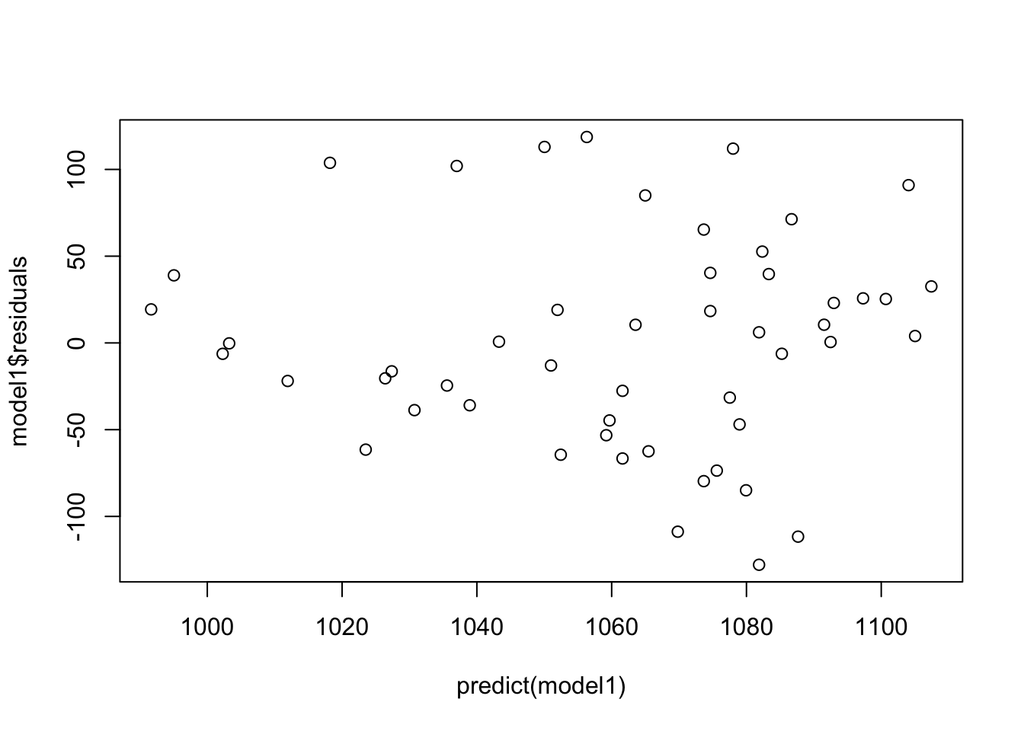

```r
plot(model1$residuals~predict(model1))
```

This plot shows that the variance in the errors is NOT constant, but rather gets bigger as our x increases. This is a sign of heteroskedasticity.

Question 5.

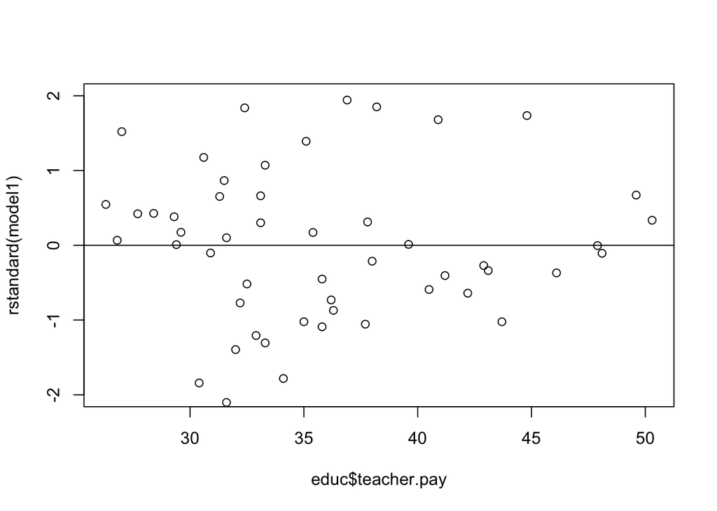

```r
plot(rstandard(model1)~educ$teacher.pay,ylim=c(-2,2))
abline(h=0)
```

This shows our errors plotted around a regressor at 0. It is strange that there are no negative errors before teacher pay is at 30,000 dollars. But otherwise, the errors seem to be pretty even on the top and the bottom of the line from there on after.

Question 6.

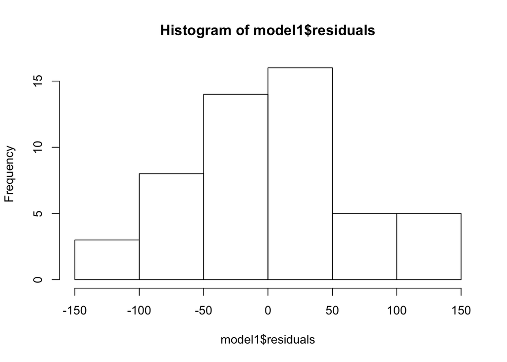

```r
hist(model1$residuals)
```

This looks like a pretty normal curve to me!

Question 7.

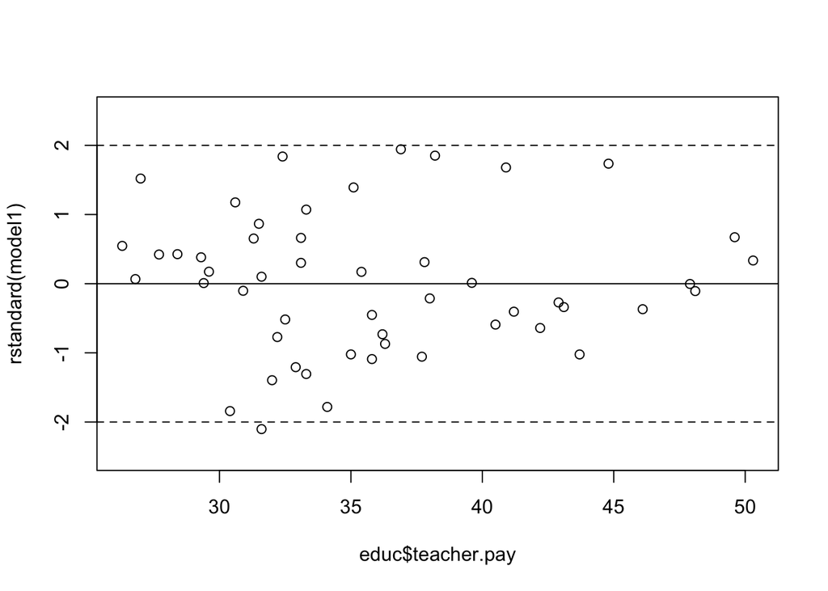

```r
plot(rstandard(model1)~educ$teacher.pay, ylim=c(-2.5,2.5))
abline(h=0)
abline(h=2, lty=2)
abline(h=-2, lty=2)
```

```r
#There aren't any really huge outliers in residuals, there is only one that actually goes past -2.
summary(round(cooks.distance(model1),2))
```

```
##    Min. 1st Qu.  Median    Mean 3rd Qu.    Max.
## 0.00000 0.00000 0.01000 0.01627 0.02000 0.10000
```

This table shows very small leverage in our outliers.

Question 8.

```r
summary(model1)
```

```
##
## Call:
## lm(formula = sat.mathandverbal ~ teacher.pay, data = educ)
##
## Residuals:
##      Min       1Q   Median       3Q      Max
## -127.870  -41.712    0.518   35.759  118.694
##
## Coefficients:
##             Estimate Std. Error t value Pr(>|t|)
## (Intercept) 1234.292     51.054  24.176   <2e-16 ***
## teacher.pay   -4.823      1.402  -3.441   0.0012 **
## ---
## Signif. codes:  0 '***' 0.001 '**' 0.01 '*' 0.05 '.' 0.1 ' ' 1
##
## Residual standard error: 61.72 on 49 degrees of freedom
## Multiple R-squared:  0.1946, Adjusted R-squared:  0.1781
## F-statistic: 11.84 on 1 and 49 DF,  p-value: 0.001196
```

This table shows us that when you increase teacher pay by one unit, or one thousand dollars, the average combined math and verbal SAT score drops by 4.8 points. Which, to me, is strange.

Problem 2

Question 9.

```r
library(knitr)
library(dplyr)
kable(round(cor(educ %>% select(-state,-region)),2))
```

[output not shown]

Question 10.

```r
educ.sub = educ %>% dplyr::select(-state,-region,-sat.math,-sat.verbal)
mod.list = list(m1 = lm(sat.mathandverbal ~ population + percent.taking,data=educ.sub),
m2 = lm(sat.mathandverbal ~ population + percent.no.hs,data=educ.sub),
m3 = lm(sat.mathandverbal ~ population + teacher.pay,data=educ.sub),
m4 = lm(sat.mathandverbal ~ percent.taking + percent.no.hs,data=educ.sub),
m5 = lm(sat.mathandverbal ~ percent.taking + teacher.pay,data=educ.sub),
m6 = lm(sat.mathandverbal ~ percent.no.hs + teacher.pay,data=educ.sub),
m7 = lm(sat.mathandverbal ~ population + percent.taking + percent.no.hs,data=educ.sub),
m8 = lm(sat.mathandverbal ~ population + percent.taking + teacher.pay,data=educ.sub),
m9 = lm(sat.mathandverbal ~ population + percent.no.hs + teacher.pay,data=educ.sub),
m10 = lm(sat.mathandverbal ~ percent.taking + percent.no.hs + teacher.pay,data=educ.sub),
m11 = lm(sat.mathandverbal ~ population + percent.taking + percent.no.hs + teacher.pay,data=educ.sub))

mod.comps = data.frame(AIC = unlist(lapply(mod.list,AIC)),BIC = unlist(lapply(mod.list,BIC)),df = unlist(lapply(lapply(mod.list,coef),length))-1)
mod.comps
```

```
##          AIC      BIC df
## m1  505.7065 513.4338  2
## m2  578.8861 586.6134  2
## m3  570.4418 578.1691  2
## m4  496.1004 503.8277  2
## m5  503.7353 511.4626  2
## m6  567.6795 575.4068  2
## m7  497.8829 507.5421  3
## m8  503.2910 512.9501  3
## m9  569.5395 579.1986  3
## m10 497.0705 506.7297  3
## m11 498.3425 509.9335  4
```

Model 4 has the lowest AIC, but model 7 is very close. However, model 4 is more simple than model seven because it only includes two parameters. So 4 is best.

Question 11.

```r
summary(lm.unrestricted <- lm(sat.mathandverbal ~ ., data = educ.sub))
```

```
##
## Call:
## lm(formula = sat.mathandverbal ~ ., data = educ.sub)
##
## Residuals:
##     Min      1Q  Median      3Q     Max
## -68.501 -18.079   4.678  19.437  64.606
##
## Coefficients:
##                  Estimate Std. Error t value Pr(>|t|)
## (Intercept)     1.163e+03  4.029e+01  28.861  < 2e-16 ***
## population     -6.558e-04  8.064e-04  -0.813   0.4203
## percent.taking -2.464e+00  2.031e-01 -12.134 6.14e-16 ***
## percent.no.hs  -2.143e+00  8.270e-01  -2.591   0.0128 *
## teacher.pay     1.116e+00  9.397e-01   1.188   0.2411
## ---
## Signif. codes:  0 '***' 0.001 '**' 0.01 '*' 0.05 '.' 0.1 ' ' 1
##
## Residual standard error: 29.99 on 46 degrees of freedom
## Multiple R-squared:  0.8215, Adjusted R-squared:  0.806
## F-statistic: 52.94 on 4 and 46 DF,  p-value: < 2.2e-16
```

```r
backAIC <- step(lm.unrestricted,direction = 'backward', k=2)
```

```
## Start:  AIC=351.61
## sat.mathandverbal ~ population + percent.taking + percent.no.hs +
##     teacher.pay
##
##                  Df Sum of Sq    RSS    AIC
## - population      1       595  41955 350.34
## - teacher.pay     1      1268  42629 351.15
## <none>                         41360 351.61
## - percent.no.hs   1      6037  47397 356.56
## - percent.taking  1    132379 173739 422.81
##
## Step:  AIC=350.34
## sat.mathandverbal ~ percent.taking + percent.no.hs + teacher.pay
##
##                  Df Sum of Sq    RSS    AIC
## - teacher.pay     1       856  42811 349.37
## <none>                         41955 350.34
## - percent.no.hs   1      7769  49724 357.00
## - percent.taking  1    132262 174217 420.95
##
## Step:  AIC=349.37
## sat.mathandverbal ~ percent.taking + percent.no.hs
##
##                  Df Sum of Sq    RSS    AIC
## <none>                         42811 349.37
## - percent.no.hs   1      9931  52742 358.01
## - percent.taking  1    186859 229670 433.04
```

```r
backBIC <- step(lm.unrestricted,direction = 'backward',k= log(nrow(educ.sub)))
```

```
## Start:  AIC=361.27
## sat.mathandverbal ~ population + percent.taking + percent.no.hs +
##     teacher.pay
##
##                  Df Sum of Sq    RSS    AIC
## - population      1       595  41955 358.07
## - teacher.pay     1      1268  42629 358.88
## <none>                         41360 361.27
## - percent.no.hs   1      6037  47397 364.29
## - percent.taking  1    132379 173739 430.54
##
## Step:  AIC=358.07
## sat.mathandverbal ~ percent.taking + percent.no.hs + teacher.pay
##
##                  Df Sum of Sq    RSS    AIC
## - teacher.pay     1       856  42811 355.16
## <none>                         41955 358.07
## - percent.no.hs   1      7769  49724 362.80
## - percent.taking  1    132262 174217 426.74
##
## Step:  AIC=355.16
## sat.mathandverbal ~ percent.taking + percent.no.hs
##
##                  Df Sum of Sq    RSS    AIC
## <none>                         42811 355.16
## - percent.no.hs   1      9931  52742 361.87
## - percent.taking  1    186859 229670 436.90
```

It is the same when you use AIC or BIC.

Question 12.

```r
summary(lm.unrestricted <- lm(sat.mathandverbal ~ ., data = educ.sub))
```

```
##
## Call:
## lm(formula = sat.mathandverbal ~ ., data = educ.sub)
##
## Residuals:
##     Min      1Q  Median      3Q     Max
## -68.501 -18.079   4.678  19.437  64.606
##
## Coefficients:
##                  Estimate Std. Error t value Pr(>|t|)
## (Intercept)     1.163e+03  4.029e+01  28.861  < 2e-16 ***
## population     -6.558e-04  8.064e-04  -0.813   0.4203
## percent.taking -2.464e+00  2.031e-01 -12.134 6.14e-16 ***
## percent.no.hs  -2.143e+00  8.270e-01  -2.591   0.0128 *
## teacher.pay     1.116e+00  9.397e-01   1.188   0.2411
## ---
## Signif. codes:  0 '***' 0.001 '**' 0.01 '*' 0.05 '.' 0.1 ' ' 1
##
## Residual standard error: 29.99 on 46 degrees of freedom
## Multiple R-squared:  0.8215, Adjusted R-squared:  0.806
## F-statistic: 52.94 on 4 and 46 DF,  p-value: < 2.2e-16
```

```r
summary(lm.restricted <- lm(sat.mathandverbal ~1,data = educ.sub))
```

```
##
## Call:
## lm(formula = sat.mathandverbal ~ 1, data = educ.sub)
##
## Residuals:
##     Min      1Q  Median      3Q     Max
## -107.18  -58.18  -17.18   61.32  133.82
##
## Coefficients:
##             Estimate Std. Error t value Pr(>|t|)
## (Intercept) 1061.176      9.533   111.3   <2e-16 ***
## ---
## Signif. codes:  0 '***' 0.001 '**' 0.01 '*' 0.05 '.' 0.1 ' ' 1
##
## Residual standard error: 68.08 on 50 degrees of freedom
```

```r
step(lm.restricted, scope=list(lower=lm.restricted, upper=lm.unrestricted), direction="forward", k=2)
```

```
## Start:  AIC=431.5
## sat.mathandverbal ~ 1
##
##                  Df Sum of Sq    RSS    AIC
## + percent.taking  1    179012  52742 358.01
## + teacher.pay     1     45092 186661 422.47
## + population      1     14004 217749 430.32
## <none>                        231753 431.50
## + percent.no.hs   1      2083 229670 433.04
##
## Step:  AIC=358.01
## sat.mathandverbal ~ percent.taking
##
##                 Df Sum of Sq   RSS    AIC
## + percent.no.hs  1    9931.0 42811 349.37
## + teacher.pay    1    3017.4 49724 357.00
## <none>                       52742 358.01
## + population     1    1057.9 51684 358.97
##
## Step:  AIC=349.37
## sat.mathandverbal ~ percent.taking + percent.no.hs
##
##               Df Sum of Sq   RSS    AIC
## <none>                     42811 349.37
## + teacher.pay  1    855.85 41955 350.34
## + population   1    182.16 42629 351.15
```

```
##
## Call:
## lm(formula = sat.mathandverbal ~ percent.taking + percent.no.hs,
##     data = educ.sub)
##
## Coefficients:
##    (Intercept)  percent.taking   percent.no.hs
##       1204.776          -2.344          -2.540
```

```r
step(lm.restricted, scope=list(lower=lm.restricted, upper=lm.unrestricted), direction="forward", k=log(nrow(educ.sub)))
```

```
## Start:  AIC=433.43
## sat.mathandverbal ~ 1
##
##                  Df Sum of Sq    RSS    AIC
## + percent.taking  1    179012  52742 361.87
## + teacher.pay     1     45092 186661 426.33
## <none>                        231753 433.43
## + population      1     14004 217749 434.19
## + percent.no.hs   1      2083 229670 436.90
##
## Step:  AIC=361.87
## sat.mathandverbal ~ percent.taking
##
##                 Df Sum of Sq   RSS    AIC
## + percent.no.hs  1    9931.0 42811 355.16
## <none>                       52742 361.87
## + teacher.pay    1    3017.4 49724 362.80
## + population     1    1057.9 51684 364.77
##
## Step:  AIC=355.16
## sat.mathandverbal ~ percent.taking + percent.no.hs
##
##               Df Sum of Sq   RSS    AIC
## <none>                     42811 355.16
## + teacher.pay  1    855.85 41955 358.07
## + population   1    182.16 42629 358.88
```

```
##
## Call:
## lm(formula = sat.mathandverbal ~ percent.taking + percent.no.hs,
##     data = educ.sub)
##
## Coefficients:
##    (Intercept)  percent.taking   percent.no.hs
##       1204.776          -2.344          -2.540
```

Question 13. They all agree on the model sat.mathandverbal~percent.taking + percent.no.hs

Question 14.

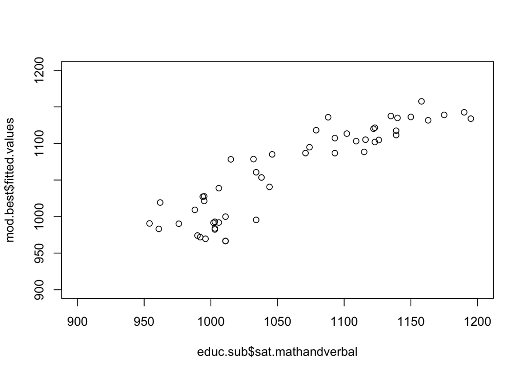

```r
mod.best = lm(sat.mathandverbal ~ percent.taking + percent.no.hs,data=educ.sub)
plot(mod.best$fitted.values ~ educ.sub$sat.mathandverbal,ylim=c(900,1200),xlim=c(900,1200))
```

I’m not sure if it is doing the best job because I feel like the relationship may be slightly curved.